# cyclist_project_case_study

Greg

2023-11-21

#Project Capstone Cyclist

##Step 1 Spreadsheet (Excel)

- Download all data files (may-oct 2023)
- Create copies to transform to xlsx documents (leave csv backup copies)
- Added ride_length (ended_at - started_at)(D2 - C2)
- Added day_of_week (WEEKDAY(started_at)) (WEEKDAY(C2)) as number
- Exported all the files to transform in RStudio

##* Complete raw dataset is hosted on Kaggle.com [click here](https://www.kaggle.com/datasets/gregoriolobo/cyclist-complete-dataset-may-oct)

##Step 2 RStudio

- Prepare environment
- Assign all files to individual dataframes numbered 5-10 (may-oct)
- Merge all dataframes into a single df_complete
- First df structure evaluation

```r
df_complete <- rbind(df_05, df_06, df_07, df_08, df_09, df_10)
skim_without_charts(df_complete)
```

Data summary

| Name | df_complete |
| --- | --- |
| Number of rows | 4067272 |
| Number of columns | 15 |
| _______________________ |  |
| Column type frequency: |  |
| character | 7 |
| numeric | 5 |
| POSIXct | 3 |
| ________________________ |  |
| Group variables | None |

**Variable type: character**

| skim_variable | n_missing | complete_rate | min | max | empty | n_unique | whitespace |
| --- | --- | --- | --- | --- | --- | --- | --- |
| ride_id | 0 | 1.00 | 13 | 23 | 0 | 4067272 | 0 |
| rideable_type | 0 | 1.00 | 11 | 13 | 0 | 3 | 0 |
| start_station_name | 633085 | 0.84 | 10 | 64 | 0 | 1533 | 0 |
| start_station_id | 633085 | 0.84 | 2 | 35 | 0 | 1465 | 0 |
| end_station_name | 671733 | 0.83 | 10 | 64 | 0 | 1537 | 0 |
| end_station_id | 671733 | 0.83 | 2 | 35 | 0 | 1467 | 0 |
| member_casual | 0 | 1.00 | 6 | 6 | 0 | 2 | 0 |

**Variable type: numeric**

| skim_variable | n_missing | complete_rate | mean | sd | p0 | p25 | p50 | p75 | p100 |
| --- | --- | --- | --- | --- | --- | --- | --- | --- | --- |
| day_of_week | 0 | 1 | 4.12 | 2.01 | 1.00 | 2.00 | 4.00 | 6.00 | 7.00 |
| start_lat | 0 | 1 | 41.90 | 0.04 | 41.63 | 41.88 | 41.90 | 41.93 | 42.07 |
| start_lng | 0 | 1 | -87.65 | 0.03 | -87.94 | -87.66 | -87.64 | -87.63 | -87.46 |
| end_lat | 5540 | 1 | 41.90 | 0.06 | 0.00 | 41.88 | 41.90 | 41.93 | 42.18 |
| end_lng | 5540 | 1 | -87.65 | 0.08 | -88.16 | -87.66 | -87.64 | -87.63 | 0.00 |

**Variable type: POSIXct**

| skim_variable | n_missing | complete_rate | min | max | median | n_unique |
| --- | --- | --- | --- | --- | --- | --- |
| started_at | 0 | 1 | 2023-05-01 00:00:33 | 2023-10-31 23:59:00 | 2023-07-29 19:22:03 | 2916057 |
| ended_at | 0 | 1 | 2023-05-01 00:04:28 | 2023-11-01 21:23:00 | 2023-07-29 19:46:04 | 2924096 |
| ride_length | 0 | 1 | 1899-12-30 22:38:19 | 1900-03-08 09:29:04 | 1899-12-31 00:10:16 | 20334 |

- Notice how started_at, ended_at and ride_length are of type POSIXct
- Change column ride_length to be calculated in seconds and as a numeric type to run calculations
- DF structure summary and evaluation

```r
skim_without_charts(df_complete)
```

Data summary

| Name | df_complete |
| --- | --- |
| Number of rows | 4067272 |
| Number of columns | 15 |
| _______________________ |  |
| Column type frequency: |  |
| character | 7 |
| numeric | 6 |
| POSIXct | 2 |
| ________________________ |  |
| Group variables | None |

**Variable type: character**

| skim_variable | n_missing | complete_rate | min | max | empty | n_unique | whitespace |
| --- | --- | --- | --- | --- | --- | --- | --- |
| ride_id | 0 | 1.00 | 13 | 23 | 0 | 4067272 | 0 |
| rideable_type | 0 | 1.00 | 11 | 13 | 0 | 3 | 0 |
| start_station_name | 633085 | 0.84 | 10 | 64 | 0 | 1533 | 0 |
| start_station_id | 633085 | 0.84 | 2 | 35 | 0 | 1465 | 0 |
| end_station_name | 671733 | 0.83 | 10 | 64 | 0 | 1537 | 0 |
| end_station_id | 671733 | 0.83 | 2 | 35 | 0 | 1467 | 0 |
| member_casual | 0 | 1.00 | 6 | 6 | 0 | 2 | 0 |

**Variable type: numeric**

| skim_variable | n_missing | complete_rate | mean | sd | p0 | p25 | p50 | p75 | p100 |
| --- | --- | --- | --- | --- | --- | --- | --- | --- | --- |
| ride_length | 0 | 1 | 1183.42 | 12108.80 | -4901.00 | 354.00 | 616.00 | 1091.00 | 5909344.00 |
| day_of_week | 0 | 1 | 4.12 | 2.01 | 1.00 | 2.00 | 4.00 | 6.00 | 7.00 |
| start_lat | 0 | 1 | 41.90 | 0.04 | 41.63 | 41.88 | 41.90 | 41.93 | 42.07 |
| start_lng | 0 | 1 | -87.65 | 0.03 | -87.94 | -87.66 | -87.64 | -87.63 | -87.46 |
| end_lat | 5540 | 1 | 41.90 | 0.06 | 0.00 | 41.88 | 41.90 | 41.93 | 42.18 |
| end_lng | 5540 | 1 | -87.65 | 0.08 | -88.16 | -87.66 | -87.64 | -87.63 | 0.00 |

**Variable type: POSIXct**

| skim_variable | n_missing | complete_rate | min | max | median | n_unique |
| --- | --- | --- | --- | --- | --- | --- |
| started_at | 0 | 1 | 2023-05-01 00:00:33 | 2023-10-31 23:59:00 | 2023-07-29 19:22:03 | 2916057 |
| ended_at | 0 | 1 | 2023-05-01 00:04:28 | 2023-11-01 21:23:00 | 2023-07-29 19:46:04 | 2924096 |

```r
glimpse(df_complete)
```

```
## Rows: 4,067,272
## Columns: 15
## $ ride_id            <chr> "0D9FA920C3062031", "92485E5FB5888ACD", "FB144B3FC8…
## $ rideable_type      <chr> "electric_bike", "electric_bike", "electric_bike", …
## $ started_at         <dttm> 2023-05-07 19:53:48, 2023-05-06 18:54:08, 2023-05-…
## $ ended_at           <dttm> 2023-05-07 19:58:32, 2023-05-06 19:03:35, 2023-05-…
## $ ride_length        <dbl> 284, 567, 255, 771, 534, 939, 2020, 291, 759, 178, …
## $ day_of_week        <dbl> 1, 7, 1, 4, 3, 3, 3, 7, 2, 6, 7, 6, 2, 5, 7, 2, 2, …
## $ start_station_name <chr> "Southport Ave & Belmont Ave", "Southport Ave & Bel…
## $ start_station_id   <chr> "13229", "13229", "13162", "13196", "TA1308000047",…
## $ end_station_name   <chr> NA, NA, NA, "Damen Ave & Cortland St", "Southport A…
## $ end_station_id     <chr> NA, NA, NA, "13133", "13229", "TA1306000029", "1343…
## $ start_lat          <dbl> 41.93941, 41.93948, 41.85379, 41.89456, 41.95708, 4…
## $ start_lng          <dbl> -87.66383, -87.66385, -87.64672, -87.65345, -87.664…
## $ end_lat            <dbl> 41.93000, 41.94000, 41.86000, 41.91598, 41.93948, 4…
## $ end_lng            <dbl> -87.65000, -87.69000, -87.65000, -87.67733, -87.663…
## $ member_casual      <chr> "member", "member", "member", "member", "member", "…
```

```r
str(df_complete)
```

```
## tibble [4,067,272 × 15] (S3: tbl_df/tbl/data.frame)
##  $ ride_id           : chr [1:4067272] "0D9FA920C3062031" "92485E5FB5888ACD" "FB144B3FC8300187" "DDEB93BC2CE9AA77" ...
##  $ rideable_type     : chr [1:4067272] "electric_bike" "electric_bike" "electric_bike" "classic_bike" ...
##  $ started_at        : POSIXct[1:4067272], format: "2023-05-07 19:53:48" "2023-05-06 18:54:08" ...
##  $ ended_at          : POSIXct[1:4067272], format: "2023-05-07 19:58:32" "2023-05-06 19:03:35" ...
##  $ ride_length       : num [1:4067272] 284 567 255 771 534 939 2020 291 759 178 ...
##  $ day_of_week       : num [1:4067272] 1 7 1 4 3 3 3 7 2 6 ...
##  $ start_station_name: chr [1:4067272] "Southport Ave & Belmont Ave" "Southport Ave & Belmont Ave" "Halsted St & 21st St" "Carpenter St & Huron St" ...
##  $ start_station_id  : chr [1:4067272] "13229" "13229" "13162" "13196" ...
##  $ end_station_name  : chr [1:4067272] NA NA NA "Damen Ave & Cortland St" ...
##  $ end_station_id    : chr [1:4067272] NA NA NA "13133" ...
##  $ start_lat         : num [1:4067272] 41.9 41.9 41.9 41.9 42 ...
##  $ start_lng         : num [1:4067272] -87.7 -87.7 -87.6 -87.7 -87.7 ...
##  $ end_lat           : num [1:4067272] 41.9 41.9 41.9 41.9 41.9 ...
##  $ end_lng           : num [1:4067272] -87.7 -87.7 -87.7 -87.7 -87.7 ...
##  $ member_casual     : chr [1:4067272] "member" "member" "member" "member" ...
```

```r
colnames(df_complete)
```

```
##  [1] "ride_id"            "rideable_type"      "started_at"
##  [4] "ended_at"           "ride_length"        "day_of_week"
##  [7] "start_station_name" "start_station_id"   "end_station_name"
## [10] "end_station_id"     "start_lat"          "start_lng"
## [13] "end_lat"            "end_lng"            "member_casual"
```

- Verify columns member_casual and rideable_type to make sure all the values are correct

```r
table(df_complete$member_casual)
```

```
##
##  casual  member
## 1616605 2450667
```

```r
table(df_complete$rideable_type)
```

```
##
##  classic_bike   docked_bike electric_bike
##       1958267         62447       2046558
```

- Create new aggregation columns as date, month, day, and day_of_week to make further calculations
- Create a new v2 df with cleaned data and removed negative erroneous values in ride_length column (167 records removed)

```r
df_complete_v2 <- df_complete[!df_complete$ride_length<0,]
```

- Descriptive analysis of ride_length column

```r
summary(df_complete_v2$ride_length)
```

```
##    Min. 1st Qu.  Median    Mean 3rd Qu.    Max.
##       0     354     616    1183    1091 5909344
```

- Comparative statistics between members and casual riders

```r
aggregate(df_complete_v2$ride_length ~ df_complete_v2$member_casual, FUN = mean)
```

```
##   df_complete_v2$member_casual df_complete_v2$ride_length
## 1                       casual                  1776.2257
## 2                       member                   792.4751
```

```r
aggregate(df_complete_v2$ride_length ~ df_complete_v2$member_casual, FUN = median)
```

```
##   df_complete_v2$member_casual df_complete_v2$ride_length
## 1                       casual                        758
## 2                       member                        542
```

```r
aggregate(df_complete_v2$ride_length ~ df_complete_v2$member_casual, FUN = max)
```

```
##   df_complete_v2$member_casual df_complete_v2$ride_length
## 1                       casual                    5909344
## 2                       member                      90031
```

```r
aggregate(df_complete_v2$ride_length ~ df_complete_v2$member_casual, FUN = min)
```

```
##   df_complete_v2$member_casual df_complete_v2$ride_length
## 1                       casual                          0
## 2                       member                          0
```

- Comparative average ride time by each day for members vs casual users

```r
aggregate(df_complete_v2$ride_length ~ df_complete_v2$member_casual + df_complete_v2$day_of_week, FUN = mean)
```

```
##    df_complete_v2$member_casual df_complete_v2$day_of_week
## 1                        casual                     Friday
## 2                        member                     Friday
## 3                        casual                     Monday
## 4                        member                     Monday
## 5                        casual                   Saturday
## 6                        member                   Saturday
## 7                        casual                     Sunday
## 8                        member                     Sunday
## 9                        casual                   Thursday
## 10                       member                   Thursday
## 11                       casual                    Tuesday
## 12                       member                    Tuesday
## 13                       casual                  Wednesday
## 14                       member                  Wednesday
##    df_complete_v2$ride_length
## 1                   1737.8528
## 2                    792.1501
## 3                   1747.3033
## 4                    752.3567
## 5                   1979.6630
## 6                    876.8853
## 7                   2042.1901
## 8                    884.4506
## 9                   1568.7603
## 10                   755.6269
## 11                  1586.4772
## 12                   762.4189
## 13                  1530.0853
## 14                   754.0380
```

- Notice weekdays are in alphabetical order, change them in sequential order
- Comparative average ride time by each day for members vs casual users

```r
aggregate(df_complete_v2$ride_length ~ df_complete_v2$member_casual + df_complete_v2$day_of_week, FUN = mean)
```

```
##    df_complete_v2$member_casual df_complete_v2$day_of_week
## 1                        casual                     Sunday
## 2                        member                     Sunday
## 3                        casual                     Monday
## 4                        member                     Monday
## 5                        casual                    Tuesday
## 6                        member                    Tuesday
## 7                        casual                  Wednesday
## 8                        member                  Wednesday
## 9                        casual                   Thursday
## 10                       member                   Thursday
## 11                       casual                     Friday
## 12                       member                     Friday
## 13                       casual                   Saturday
## 14                       member                   Saturday
##    df_complete_v2$ride_length
## 1                   2042.1901
## 2                    884.4506
## 3                   1747.3033
## 4                    752.3567
## 5                   1586.4772
## 6                    762.4189
## 7                   1530.0853
## 8                    754.0380
## 9                   1568.7603
## 10                   755.6269
## 11                  1737.8528
## 12                   792.1501
## 13                  1979.6630
## 14                   876.8853
```

- Analyze ridership data by type and weekday

```r
df_complete_v2 %>%
  group_by(member_casual, day_of_week) %>%                #groups by usertype and weekday
  summarise(number_of_rides = n()                                       #calculates the number of rides and average duration
            ,average_duration = mean(ride_length)) %>%      #calculates the average duration
  arrange(member_casual, day_of_week)
```

```
## # A tibble: 14 × 4
## # Groups:   member_casual [2]
##    member_casual day_of_week number_of_rides average_duration
##    <chr>         <ord>                 <int>            <dbl>
##  1 casual        Sunday               272027            2042.
##  2 casual        Monday               187313            1747.
##  3 casual        Tuesday              191393            1586.
##  4 casual        Wednesday            188169            1530.
##  5 casual        Thursday             202587            1569.
##  6 casual        Friday               245032            1738.
##  7 casual        Saturday             329993            1980.
##  8 member        Sunday               281910             884.
##  9 member        Monday               329623             752.
## 10 member        Tuesday              384016             762.
## 11 member        Wednesday            381984             754.
## 12 member        Thursday             385041             756.
## 13 member        Friday               358388             792.
## 14 member        Saturday             329629             877.
```

- Viz the number of rides by rider type and weekday

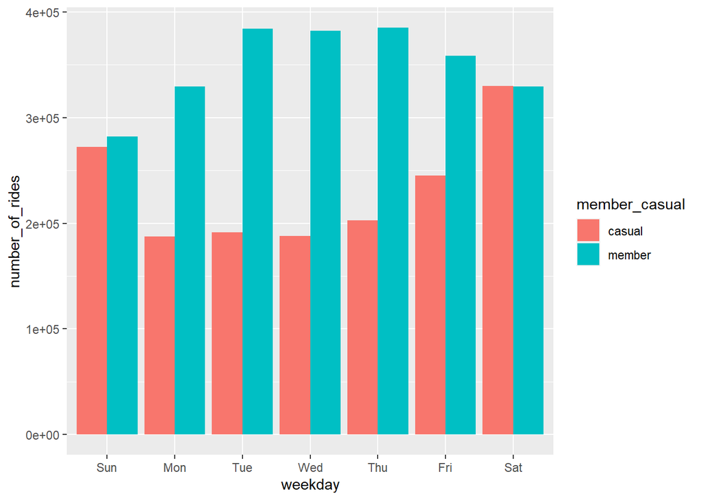

```r
df_complete_v2 %>%
  mutate(weekday = wday(started_at, label = TRUE)) %>%
  group_by(member_casual, weekday) %>%
  summarise(number_of_rides = n(), average_duration = mean(ride_length)) %>%
  arrange(member_casual, weekday)  %>%
  ggplot(aes(x = weekday, y = number_of_rides, fill = member_casual)) +
  geom_col(position = "dodge")
```

- Viz for average duration by rider type and weekday

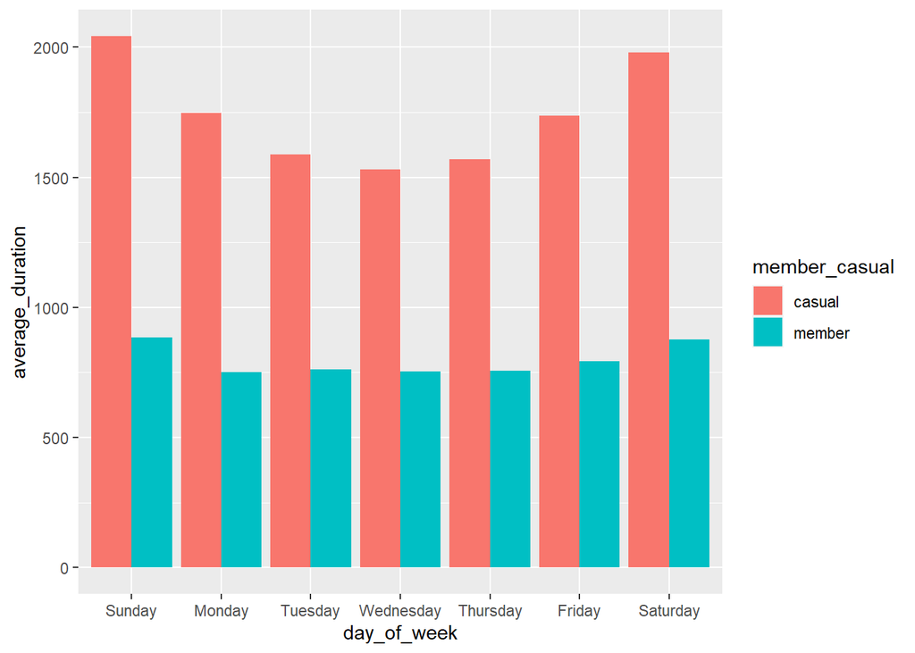

```r
df_complete_v2 %>%
  group_by(member_casual, day_of_week) %>%
  summarise(number_of_rides = n(), average_duration = mean(ride_length)) %>%
  arrange(member_casual, day_of_week)  %>%
  ggplot(aes(x = day_of_week, y = average_duration, fill = member_casual)) +
  geom_col(position = "dodge")
```

- Export file for further analysis